# SEI/CADE - 0545510 - Termo de Compromisso de Cessação (TCC)

**Ministério da Justiça - MJ**

**Conselho Administrativo de Defesa Econômica - CADE**

SEPN 515 Conjunto D, Lote 4 Ed. Carlos Taurisano, 3º andar - Bairro Asa Norte, Brasília/DF, CEP 70770-504  
Telefone: (61) 3221-8472 - www.cade.gov.br

Termo de Compromisso de Cessação

**O CONSELHO ADMINISTRATIVO DE DEFESA ECONÔMICA** (“**CADE**”), neste ato representado por seu Presidente, **Alexandre Barreto de Souza**, conforme disposto no art. 10, inciso VII, da Lei nº 12.529, de 30 de novembro de 2011, em cumprimento à decisão plenária exarada na 133<sup>a</sup> Sessão Ordinária de Julgamento, realizada em 07 de novembro de 2018 e **Schneider Electric Brasil Ltda.** (“**Schneider**” ou “**Compromissária**”), já qualificada no Processo Administrativo nº 08012.001377/2006-52 (Apartado de Acesso Restrito nº 08700.011158/2014-33), neste ato representada por seus advogados **Barbara Rosenberg**, e **José Inacio Ferraz de Almeida Prado Filho**, decidem celebrar o presente Termo de Compromisso de Cessação de Prática (“**Termo de Compromisso**”), de acordo com as cláusulas e condições seguintes, em conformidade com o art. 85 da Lei nº 12.529/11 (e antigo art. 53 da Lei nº 8.884/94, com a redação dada pela Lei nº 11.482/07) e com o Regimento Interno do CADE.

**Cláusula Primeira – Do objeto e da abrangência**

1.1. Este Termo de Compromisso tem por objetivo preservar e proteger as condições concorrenciais no mercado de produtos de distribuição e transmissão de energia no sistema de energia elétrica, bem como suspender e, caso cumpridas integralmente as obrigações nele previstas, arquivar em relação à Compromissária (*cf*. escopo da Cláusula 5) o Processo Administrativo nº 08012.001377/2006-52 (Apartado de Acesso Restrito nº 08700.011158/2014-33) (e todos e quaisquer processos dele desmembrados e a ele relacionados, presentes ou futuros), bem como à(s) pessoa(s) física(s) que, nos termos da Cláusula Sexta, decidam aderir a este Termo de Compromisso.

1.1.2. Para todos os fins e efeitos, incluem-se como feitos desmembrados ou relacionados ao Processo Administrativo nº 08012.001377/2006-52 todos e quaisquer feitos que investiguem os mesmos fatos, eventos ou condutas; sem prejuízo de outros que venham a ser posteriormente identificados, incluindo, mas não se limitando aos seguintes feitos: Processo Administrativo nº 08700.004532/2016-14, Processo Administrativo nº 08700.005146/2015-51, Processo Administrativo nº 08700.005147/2015-03 e Processo Administrativo nº 08700.003855/2018-44. Todos os feitos desmembrados ou relacionados ao Processo Administrativo nº 08012.001377/2006-52 são incorporados ao presente Termo sem qualquer obrigação para a Compromissária (ainda que não expressamente mencionados) e serão todos suspensos por força deste Termo e, caso cumpridas integralmente as obrigações aqui previstas, arquivados em relação à Compromissária (*cf*. escopo da Cláusula 5).

1.1.3. Eventual abertura de novo processo administrativo que tenha por objeto os mesmos fatos atualmente sob investigação neste processo ou em quaisquer feitos dele desmembrados ou a ele relacionados, importará em sua incorporação ao presente Termo sem qualquer obrigação para a Compromissária, sem prejuízo de instauração dos procedimentos previstos em lei para os fatos fora do escopo do Processo Administrativo nº 08012.001377/2006-52 ou de seus feitos desmembrados ou relacionados.

**Cláusula Segunda – Do reconhecimento de participação na conduta**

2.1. Nos termos das exigências contidas na legislação aplicável, a celebração deste Termo de Compromisso importa no reconhecimento dos fatos relacionados à conduta investigada nos autos do Processo Administrativo nº 08012.001377/2006-52 (Apartado de Acesso Restrito nº 08700.011158/2014-33) (e nos autos dos processos dele desmembrados e a ele relacionados), nos termos indicados na Cláusula 2.2. abaixo.

2.2. A participação da Compromissária na conduta investigada refere-se a fatos relacionados ao mercado brasileiro de subestações de força à base de AIS, incluindo projetos das próprias subestações AIS assim como componentes ou partes da subestação. Tais fatos incluem, ao menos, os eventos no período entre 1998 até 2004[1], nos mercados de produtos de transmissão e distribuição de energia elétrica (incluindo disjuntores, transformadores de instrumento e P&C), nos termos do relato de Siemens Ltda. (sucessora legal da VA Tech Transmissão e Distribuição Ltda.), Ailton Fabiano Vendramini, Amaury Eduardo Carneiro Santos, Carlos Alberto Alvim de Almeida Prado, Carlos Eduardo de Almeida Fabbro, Gilberto Luis Schaefer, Luis Eduardo Gonçalves Bucciarelli, e outros, no Requerimento nº 08700.008152/2016-41, assim como os eventos no período entre agosto de 2001 a janeiro de 2005, no mercado de P&C, nos termos do relato de Renato Meirelles no Requerimento nº 08700.005299/2016-89

2.3. A Compromissária e o CADE reconhecem que as declarações, obrigações e efeitos do presente Termo de Compromisso limitam-se aos mercados brasileiros e ao território nacional, e não têm efeitos em outras jurisdições ou territórios estrangeiros. Nenhuma referência constante neste documento tem a intenção de ser, ou deve ser considerada como sendo, reconhecimento de qualquer fato, prática ou conduta cujos impactos teriam sido causados fora do território brasileiro.

**Cláusula Terceira - Das Obrigações da Compromissária**

3.1. Contribuição Pecuniária – A Compromissária obriga-se ao pagamento de contribuição pecuniária conforme abaixo (detalhado no Anexo I deste Termo).

3.1.1. A Compromissária obriga-se a recolher contribuição pecuniária no valor de R$12.326.913,69 (doze milhões, trezentos e vinte e seis mil, novecentos e treze reais e sessenta e nove centavos) ao Fundo de Defesa dos Direitos Difusos, a ser paga em parcela única, em até 90 dias a partir da data de publicação da homologação deste Termo de Compromisso no Diário Oficial da União.

3.1.2. O pagamento da contribuição pecuniária poderá ser feito mediante o recolhimento de GRU (Guia de Recolhimento da União) ao Fundo de Defesa dos Direitos Difusos ([código de recolhimento: 20080-8; UG / Gestão: 303001/ 30211]) ou por meio de transferência bancária ([Código do Banco: 001 (Banco do Brasil); Agência: 1607-1 (Agência Governo - DF); Conta corrente: 170500-8 (Conta Única do Tesouro Nacional no BB); Código identificador: 3030013021120039]), à escolha da Compromissária. A contribuição pecuniária poderá ser recolhida diretamente pela Compromissária ou por qualquer empresa de seu grupo econômico.

3.1.3. De forma a demonstrar o recolhimento da contribuição pecuniária acima, a Compromissária obriga-se a apresentar ao CADE cópia autenticada do comprovante de pagamento no prazo de até 15 (quinze) dias após a sua realização. O comprovante de transferência bancária valerá como comprovante de pagamento, para todos os fins e efeitos.

3.2. Conduta Futura – A Compromissária obriga-se a:

3.2.1. De forma irretratável e irrevogável, a cessar a prática de qualquer das condutas investigadas no Processo Administrativo nº 08012.001377/2006-52 (Apartado de Acesso Restrito nº 08700.011158/2014-33);

3.2.2. Portar-se com honestidade, lealdade e boa-fé durante o cumprimento dessas obrigações;

3.2.3. Não realizar nenhum ato e não se omitir de qualquer forma que possa prejudicar o regular andamento das investigações desenvolvidas pelo CADE; portando-se, assim, de maneira condizente com as obrigações e manifestações de vontade neste Termo de Compromisso assumidas.

**Cláusula Quarta – Da Suspensão e do Arquivamento do Processo Administrativo**

4.1. O Processo Administrativo nº 08012.001377/2006-52 (Apartado de Acesso Restrito nº 08700.011158/2014-33) e todos e quaisquer processos dele desmembrados e a ele relacionados, presentes ou futuros, ficarão suspensos em relação à Compromissária (*cf*. escopo da Cláusula 5) até julgamento final pelo Tribunal Administrativo de Defesa Econômica, quando será avaliado o cumprimento das obrigações previstas neste Termo de Compromisso, ou até a decretação de Descumprimento deste Termo de Compromisso pelo CADE, nos termos da Cláusula Sétima, o que acontecer primeiro.

4.2. Constatado o cumprimento integral de todas as obrigações previstas na Cláusula Terceira, o Processo Administrativo nº 08012.001377/2006-52 (Apartado de Acesso Restrito nº 08700.011158/2014-33) e todos e quaisquer processos dele desmembrados e a ele relacionados, presentes ou futuros, serão arquivados em relação à Compromissária (*cf*. escopo da Cláusula 5), nos termos do art. 85, §9º da Lei nº 12.529/2011, encerrando, de modo irrevogável e irretratável, toda e qualquer responsabilidade da Compromissária (*cf*. escopo da Cláusula 5) em relação aos fatos investigados no Processo Administrativo mencionado e todos e quaisquer processos dele desmembrados e a ele relacionados, presentes ou futuros.

**Cláusula Quinta – Do Escopo do Termo de Compromisso**

5.1. O CADE reconhece que os efeitos do presente Termo se estendem da Compromissária a todas as pessoas jurídicas e entidades relacionadas ao Grupo Schneider (inclusive aquelas adquiridas ou alienadas, seja antes, durante ou depois dos fatos sob investigação), bem como aos negócios/unidades adquiridos ou alienados pelo Grupo Schneider (seja antes, durante ou depois dos fatos sob investigação).

5.2. Eventual inclusão de qualquer um destes como representados do aludido Processo Administrativo ou de processos dele desmembrados ou a ele relacionados, ou abertura de novo processo administrativo que tenha por objeto os mesmos fatos atualmente sob investigação, importará em sua incorporação ao presente Termo sem qualquer obrigação para ele ou para a Compromissária, sem prejuízo de instauração dos procedimentos previstos em lei para os fatos fora do escopo do Processo Administrativo nº 08012.001377/2006-52 (Apartado de Acesso Restrito nº 08700.011158/2014-33) (e processos dele desmembrados ou a ele relacionados, presentes ou futuros).

5.3. O presente Termo, uma vez cumprido em sua integralidade, encerra o Processo Administrativo nº 08012.001377/2006-52 (Apartado de Acesso Restrito nº 08700.011158/2014-33) (e processos dele desmembrados ou a ele relacionados, presentes ou futuros) de maneira definitiva, sem exceção, para a Compromissária e para as pessoas jurídicas e entidades descritas nas cláusulas 5.1 e 5.2 acima (*cf*. escopo da Cláusula 5).

**Cláusula Sexta – Da Adesão de Pessoas Físicas**

6.1. Pessoas físicas que, à época dos fatos investigados, trabalhavam para a Compromissária, para qualquer sociedade empresária que tenha sido adquirida ou vendida pela Compromissária ou pelo Grupo Schneider, ou por qualquer sociedade empresária do Grupo Schneider, poderão aderir a este Termo de Compromisso respeitadas as seguintes condições:

6.1.1. A Pessoa Física enquadrada na Cláusula 6.1. (doravante "**Funcionário**"), deverá protocolar petição manifestando seu interesse em aderir a este Termo de Compromisso, e, consequentemente, em assumir as obrigações que lhe forem aplicáveis;

6.1.2. O pedido deverá ser formulado nos autos do Requerimento nº 08700.002526/2018-86 e deverá conter o documento previsto no Anexo II deste Termo de Compromisso devidamente preenchido;

6.1.3. Nenhuma ressalva quanto às condições e obrigações estipuladas neste Termo de Compromisso poderá ser feita pelo Funcionário que pretenda a ele aderir;

6.1.4. O Gabinete do Relator deste Termo de Compromisso, verificando o devido preenchimento do Anexo II, em especial o cumprimento da Cláusula 6.4, e que nenhuma ressalva nos termos da Cláusula 6.1.3 foi feita, recomendará a aceitação do pedido de adesão ao Presidente do Tribunal do CADE, que submeterá o pedido de adesão à homologação do Plenário do CADE;

6.1.5. Havendo deferimento do pedido pelo Tribunal Administrativo do CADE, será juntada uma cópia do pedido e da decisão que o deferiu aos autos do Processo Administrativo nº 08012.001377/2006-52 (Apartado de Acesso Restrito nº 08700.011158/2014-33).

6.2. A presente cláusula não impede a propositura pelo Funcionário de requerimento próprio para negociação de Termo de Compromisso sob novas condições.

6.2.1. A apresentação do requerimento previsto na cláusula 6.2 implica a preclusão do direito de adesão previsto nesta cláusula.

6.2.2. O indeferimento do pedido de adesão não prejudica a possibilidade de o Funcionário requerer a negociação de novo Termo de Compromisso.

6.3. Com a adesão, o Funcionário assumirá integralmente as obrigações previstas na Cláusula 3.2.

6.4. Com a adesão, o Funcionário se comprometerá a recolher ao Fundo de Direitos Difusos contribuição pecuniária, observados os seguintes critérios:

6.4.1. Funcionários que ocuparam cargos de administrador na Schneider, em qualquer sociedade empresária que tenha sido adquirida ou vendida pela Schneider ou pelo Grupo Schneider, ou em qualquer sociedade empresária do Grupo Schneider na época dos fatos investigados obrigar-se-ão a recolher o valor de R$ 123.269,14 (cento e vinte e três mil, duzentos e sessenta e nove reais e catorze centavos), devendo o pedido de adesão ser proposto em até 6 (seis) meses após a publicação da homologação do presente Termo no Diário Oficial da União, ou de R$ 184.903,71 (cento e oitenta e quatro mil, novecentos e três reais, e setenta e um centavos), se após esse prazo.

6.4.2. Funcionários que não se incluam na Cláusula 6.4.1 obrigar-se-ão a recolher o valor de R$ 50.000,00 (cinquenta mil reais), se o pedido de adesão for proposto em até 6 (seis) meses após a publicação da homologação do presente Termo no Diário Oficial da União, ou de R$ 75.000,00 (setenta e cinco mil reais), se após esse prazo.

6.4.3. A contribuição pecuniária deverá ser paga pelo Funcionário em até 60 (sessenta) dias após a publicação do deferimento do pedido de adesão pelo Tribunal Administrativo do CADE no Diário Oficial da União.

6.4.4. O pagamento da contribuição pecuniária poderá ser feito mediante o recolhimento de GRU (Guia de Recolhimento da União) ao Fundo de Defesa dos Direitos Difusos ([código de recolhimento: 20080-8; UG / Gestão: 303001/ 30211]) ou por meio de transferência bancária ([Código do Banco: 001 (Banco do Brasil); Agência: 1607-1 (Agência Governo - DF); Conta corrente: 170500-8 (Conta Única do Tesouro Nacional no BB); Código identificador: 3030013021120039]), à escolha do Funcionário.

6.4.5. De forma a demonstrar o recolhimento da contribuição pecuniária acima, o Funcionário obriga-se a apresentar ao CADE cópia autenticada do comprovante de pagamento no prazo de até 15 (quinze) dias após a sua realização. O comprovante de transferência bancária valerá como comprovante de pagamento, para todos os fins e efeitos.

6.5. A presente cláusula vigerá pelo prazo de (*a*) 6 (seis) meses contados a partir da data de publicação da homologação deste Termo de Compromisso no Diário Oficial da União, para o funcionário ou ex-funcionário que for representado no Processo Administrativo nº 08012.001377/2006-52 (Apartado de Acesso Restrito nº 08700.011158/2014-33) ou nos processos presentes dele desmembrados ou a ele relacionados na data de publicação da homologação do presente Termo no Diário Oficial da União; e (*b*) 60 (sessenta) dias, contados a partir da publicação no Diário Oficial da União do despacho de instauração de processo administrativo em seu desfavor, para o funcionário ou ex-funcionário que não for representado no Processo Administrativo nº 08012.001377/2006-52 (Apartado de Acesso Restrito nº 08700.011158/2014-33) ou nos processos presentes dele desmembrados ou a ele relacionados na data de publicação da homologação do presente Termo no Diário Oficial da União.

6.6. O pedido de adesão deferido pelo Tribunal Administrativo do CADE importa o reconhecimento, pelo Funcionário, de sua participação na conduta investigada, nos termos da Cláusula Segunda.

6.7. A adesão do Funcionário ao presente Termo de Compromisso importará a suspensão e eventual posterior arquivamento do Processo Administrativo nº 08012.001377/2006-52 (Apartado de Acesso Restrito nº 08700.011158/2014-33) (e processos presentes dele desmembrados ou a ele relacionados) ou qualquer outro processo administrativo instaurado para apurar os fatos investigados, nos termos e condições previstos na Cláusula Quarta.

6.7.1. O descumprimento do Termo de Compromisso por qualquer pessoa física abrangida no escopo definido conforme a Cláusula Sexta não prejudicará o cumprimento pela Compromissária. Cada parte é responsável exclusivamente pela sua própria conduta para fins de atendimento das obrigações assumidas nas Cláusulas 3 e 6. Eventual atraso ou inadimplemento por uma parte não importará em responsabilidade nem inadimplemento pela parte que que tenha adimplido regularmente as suas obrigações.

**Cláusula Sétima – Do Descumprimento do Termo de Compromisso**

7.1. O eventual descumprimento do Termo de Compromisso pela Compromissária ou Funcionário que tenha a ele aderido, nos termos da Cláusula Sexta, deverá ser obrigatoriamente declarado pelo Tribunal Administrativo do CADE, após procedimento administrativo de apuração, nos autos do próprio Requerimento de nº 08700.002526/2018-86, em que será resguardado ao Compromissário ou ao Funcionário supostamente inadimplente o direito à ampla defesa para demonstração do cumprimento das obrigações, incluindo a possibilidade de apresentação de provas.

7.2. Uma vez constatado, pelo Tribunal Administrativo do CADE, o descumprimento de quaisquer obrigações previstas na Cláusula Terceira deste Termo de Compromisso, o Processo Administrativo nº 08012.001377/2006-52 (Apartado de Acesso Restrito nº 08700.011158/2014-33) (e processos dele desmembrados ou a ele relacionados) voltarão a tramitar em face da Compromissária ou do Funcionário inadimplente, sendo-lhe garantido direito de defesa no curso das investigações nas mesmas condições dos demais representados e nos termos da lei.

7.3. No caso de atraso injustificado e sem consentimento prévio do recolhimento da contribuição pecuniária prevista na Cláusula 3.1.1, ou da apresentação do comprovante de pagamento prevista na Cláusula 3.1.3, por prazo inferior a 30 (trinta) dias a contar do vencimento, a Compromissária estará sujeita, exclusivamente, a uma multa diária no valor de R$ 5.000,00 (cinco mil reais).

7.4. No caso de atraso injustificado e sem consentimento prévio do recolhimento da contribuição pecuniária prevista na Cláusula 6.4, ou da apresentação do comprovante de pagamento prevista na Cláusula 6.4.4, por prazo inferior a 30 (trinta) dias a contar do vencimento, o Funcionário inadimplente estará sujeito, exclusivamente, a uma multa diária no valor de R$ 1.000,00 (hum mil reais).

7.5. O atraso injustificado e sem consentimento prévio no recolhimento da contribuição pecuniária, por prazo superior a 30 (trinta) dias a contar de seu vencimento, será caracterizado como desídia da Compromissária ou do Funcionário inadimplente, com a consequente declaração definitiva de descumprimento integral do presente Termo de Compromisso pelo Tribunal Administrativo do CADE.

7.6. A declaração de descumprimento integral do Termo de Compromisso implicará a imposição de multa à Compromissária no valor de R$ 1.000.000,00 (hum milhão reais) e, se aplicável, ao Funcionário no valor R$ 1.000,00 (hum mil reais).

**Cláusula Oitava – Da Execução**

8.1. O presente Termo de Compromisso constitui título executivo extrajudicial, nos termos do art. 85, § 8º da Lei 12.529/11.

**Cláusula Nona – Da Publicação**

9.1. O Termo de Compromisso será divulgado no momento de sua apreciação pelo Plenário do CADE, e será tornado público após a sua homologação, nos termos do art. 85, § 7º da Lei nº 12.529/11, mantida a confidencialidade dos termos da negociação.

**Cláusula Décima – Das Notificações**

10.1. Todas as notificações e outras comunicações expedidas à Compromissária deverão ser enviadas para o seguinte endereço:

**Barbosa Müssnich Aragão Advogados**

Barbara Rosenberg e José Inacio Ferraz de Almeida Prado Filho

Av. Pres. Juscelino Kubitschek, 1455, 8º andar

CEP 04543-011 – São Paulo/SP – Brasil

Tel.: (11) 2179-4559

Fax: (11) 2179-5322

**brr@bmalaw.com.br**

**jip@bmalaw.com.br**

E por estarem de acordo, assinam o presente Termo de Compromisso na forma eletrônica, com 2 (duas) testemunhas abaixo designadas:

Brasília, **8 de novembro de 2018**

**CONSELHO ADMINISTRATIVO DE DEFESA ECONÔMICA**

ALEXANDRE BARRETO DE SOUZA – Presidente

**SCHNEIDER ELECTRIC BRASIL LTDA.**

p.p. Bárbara Rosenberg

OAB/SP 156.832

José Inácio Ferraz de Almeida Prado Filho

OAB/SP 234.668

**TESTEMUNHAS**:

| Stephanie Vendemiatto Penereiro RG: 37.469.635-4 CPF: 322.736.558-86 | Beatriz Bellintani RG: 50.160.904-0 CPF: 411.828378-67 |
| --- | --- |

**ANEXO I -** **Memória de cálculo da Contribuição Pecuniária da Schneider**

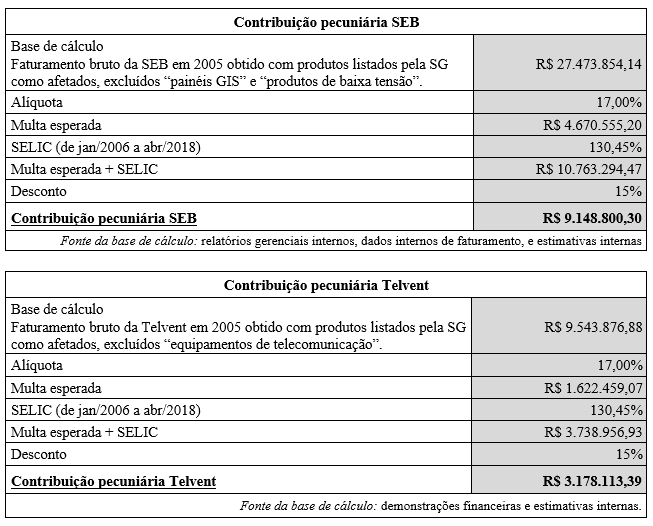

Anexo II - **Adesão ao Termo de Compromisso de Cessação**

[output not shown]

|  | Documento assinado eletronicamente por **Alexandre Barreto de Souza**, **Presidente**, em 12/11/2018, às 19:04, conforme horário oficial de Brasília e Resolução Cade nº 11, de 02 de dezembro de 2014. |
| --- | --- |

[output not shown]

|  | Documento assinado eletronicamente por **Barbara Rosenberg**, **Usuário Externo**, em 13/11/2018, às 15:24, conforme horário oficial de Brasília e Resolução Cade nº 11, de 02 de dezembro de 2014. |
| --- | --- |

|  | Documento assinado eletronicamente por **Beatriz Bellintani**, **Testemunha**, em 16/11/2018, às 10:21, conforme horário oficial de Brasília e Resolução Cade nº 11, de 02 de dezembro de 2014. |
| --- | --- |

[output not shown]

|  | A autenticidade deste documento pode ser conferida no site sei.cade.gov.br/autentica, informando o código verificador **0545510** e o código CRC **EBBE02C3**. |
| --- | --- |

| **Referência:** Processo nº 08700.002526/2018-86 | SEI nº 0545510 |
| --- | --- |